# **Analysis of Employee Performance Dataset**

## **Question 3:** Are older employees more likely to have higher Performance Ratings?

**Reason for Choosing [Visualization Type]:**  
I chose a [Visualization Type, "scatter plot"] for this question because I wanted to to able to categorize the employees by age and view their different ratings. The scatter plot would allow me to see if there were any clusters of performance ratings at a certain age.

```python
# Run Your Statistics
age_corr_rating = employee_df['Age'].corr(employee_df['Performance_Rating'])
age_corr_rating
```

```
-0.06840099619553366
```

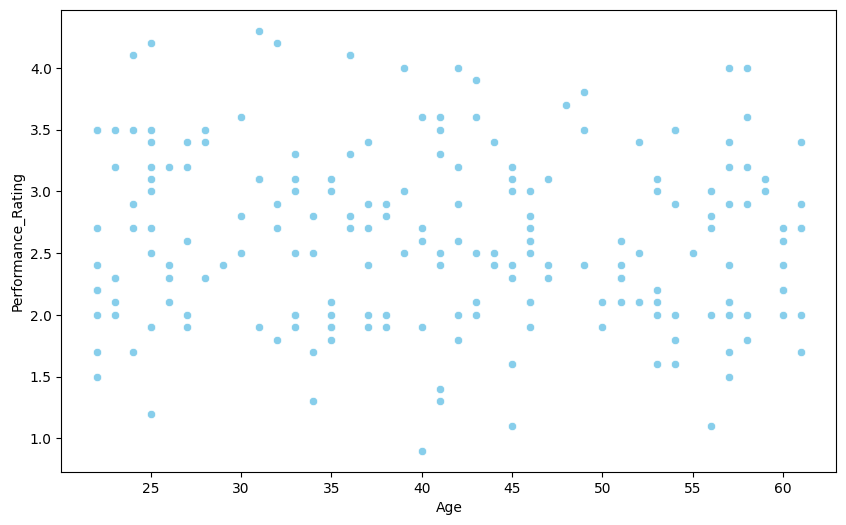

```python
# Run Your Visualization
plt.figure(figsize=(10, 6))
sns.scatterplot(data=employee_df, x='Age', y='Performance_Rating', color='skyblue')
```

#### **Insights:**

Based on the visualization, we can observe that there is no correlation between 'Age' and 'Performance_Rating'. It appears that regardless of being younger or older, performance is not affected.

## **Overall Insights & Conclusions**

After exploring the dataset and answering the three analytical questions, my key takeaways are:

If hours need to be cut, we can use this visualization to provide the minimum amount of hours that still offer the best performance. This can establish guidelines for optimal work hours that maximize productivity while preventing burnout. The organization can encourage employees to work within this range to maintain high performance.

1. Based on the visualization, we can observe that the average salary growth in the Finance 'Department' is the greatest when it comes to 'Salary' and 'Years_of_Experience.'

Finance shows the greatest salary growth with experience, and with this information, the organization can focus on retaining experienced Finance employees and use them as mentors to guide less experienced ones. Providing training and incentives can provide performance improvements and align their growth with the organization's goals.

1. Based on the visualization, we can observe that there is no correlation between 'Age' and 'Performance_Rating'. It appears that regardless of being Younger or older, performance is not affected.

Given that age doesn't impact performance, the organization can focus on merit-based promotions and rewards. Emphasis on skills, accomplishments, and contributions rather than focusing on one's age. Encouraging age diversity can bring varied perspectives and innovative solutions.

```python
!jupyter nbconvert --to html "/content/Employee_Performance_Analysis_KenJorren_Culata.ipynb"
```

```
[NbConvertApp] Converting notebook /content/Employee_Performance_Analysis_KenJorren_Culata.ipynb to html
[NbConvertApp] Writing 754406 bytes to /content/Employee_Performance_Analysis_KenJorren_Culata.html
```